# BOP analytical summary

Ellie Knott

2026-10-22

# Support for Domestic Politicians

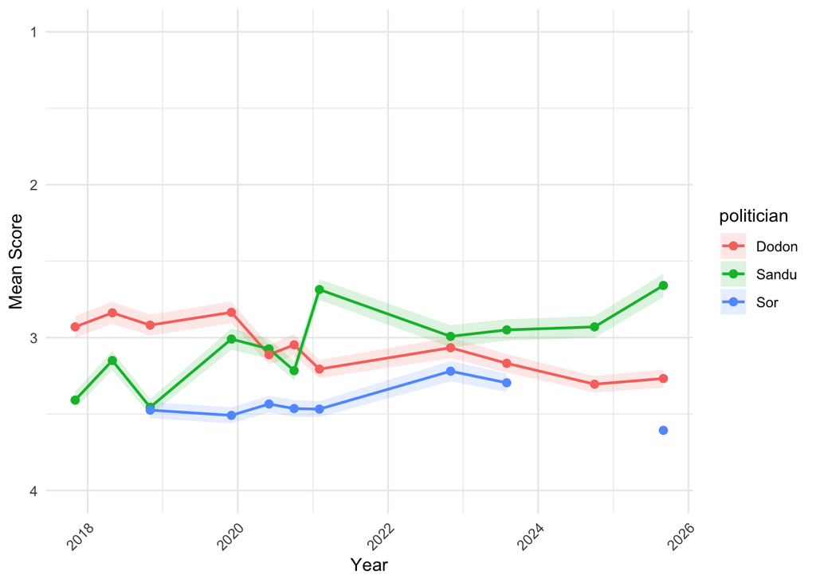

*Those identifying as Romanian are more supportive of Sandu. Those with a high level of education are more supportive of Sandu. Those who worry about corruption and war are more supportive of Sandu. Those who support unification are more supportive of Sandu. Those who support EU membership are more supportive of Sandu.*

*Those who identify as Russian or Ukrainian, or complete the survey in Russian, are less supportive of Sandu. Those who reside in Gagauzia are less supportive of Sandu. Those who support Putin are less supportive of Sandu.*

*Those who think Moldova is heading in a good direction are more supportive of Sandu and Dodon.*

*Those with a lower level of education are more supportive of Dodon. Those who name as an important media source are more supportive of Dodon.*

*Those who complete the survey in Russian are more supportive of Sor. Those who reside in the centre and north are more supportive of Sor.*

*Those who complete the survey in Russian or a higher level of education are less supportive of Dodon. Those who support EU membership and unification are less supportive of Dodon.*

*Those who worry about corrupption are less supportive of Dodon and Sor.*

*Those who reside in rural areas are less supportive of Sor.*

## Demographics

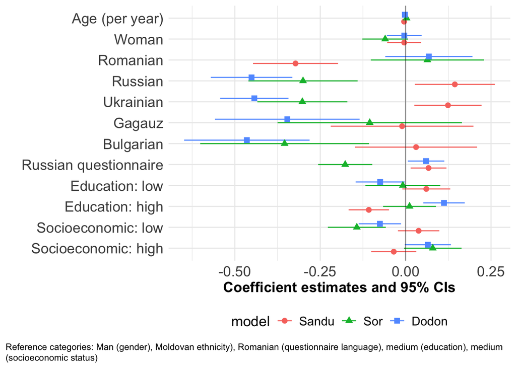

- Age & gender: not significant
- Ethnicity:
  - Romanian: significant for Sandu (+)
  - Russian: significant for Dodon & Sor (+) and Sandu (-)
  - Ukrainian: significant for Dodon & Sor (+) and Sandu (-)
  - Gagauz: (only) significant for Dodon (+)
  - Bulgarian: significant for Dodon & Sor (+)
  - Language of questionnaire: Russian significant for Sor (+) and Sandu and Dodon (-)
- Education:
  - Low: significant for Dodon (+)
  - High: significant for Sandu (+) and Dodon (-)
- Socioeconomic:
  - Low: significant for Dodon and Sor (+)
  - High: not significant

## Geography

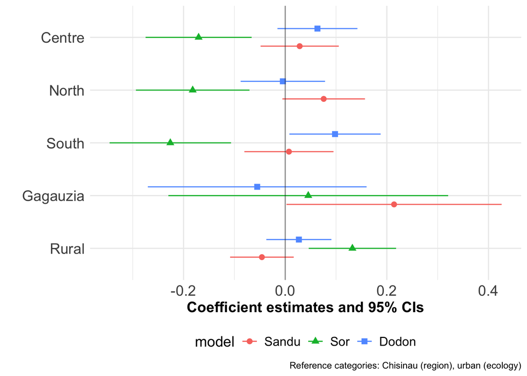

- Macro region: centre & north significant for Sor (+); others not significant
  - South: significant for Sor (+) and Dodon (-)
  - Gagauzia: significant for Sandu (-)
- Ecology: rural significant for Sor (-)

## Attitudes

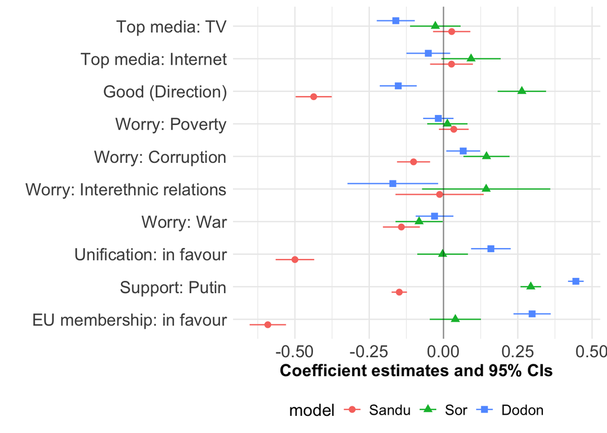

# Support for International Politicians

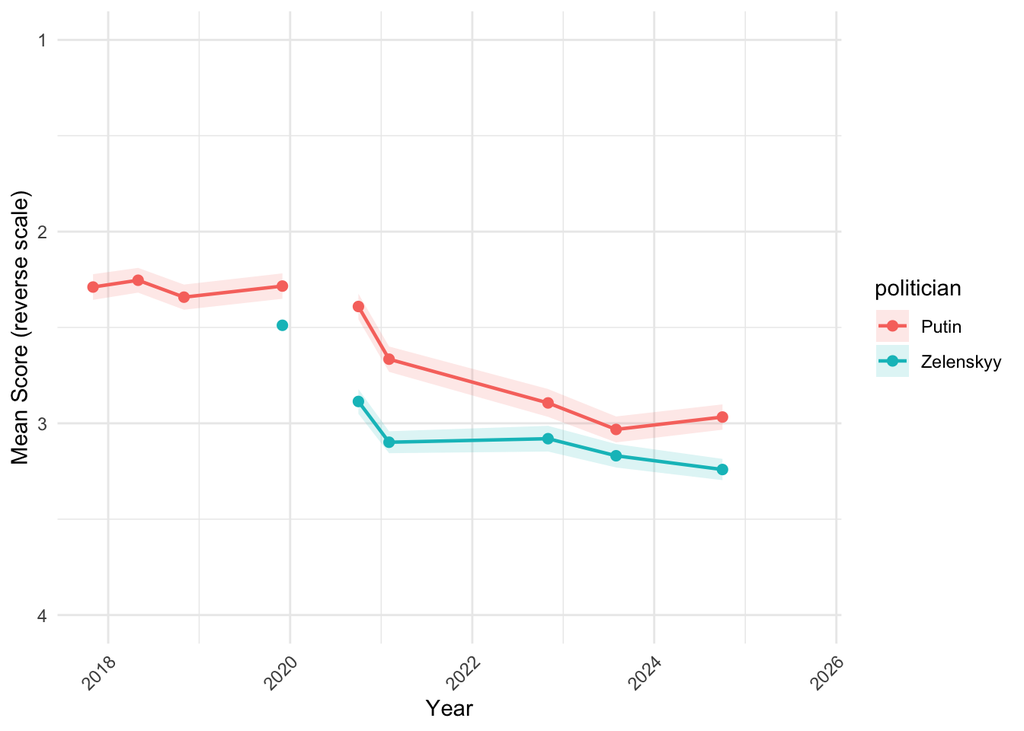

*More educated and better off are less supportive of Putin, as are those identifying as Romania.*

*Those identifying as Russian, Ukrainian, Gagauz and Bulgarian, and completing the survey in Russian, are more supportive of Putin. Those residing in Gagauzia as more supportive of Putin. Those supporting EU membership and unification as less supportive of Putin. Those worried about war and corruption as less supportive of Putin.*

## Demographics

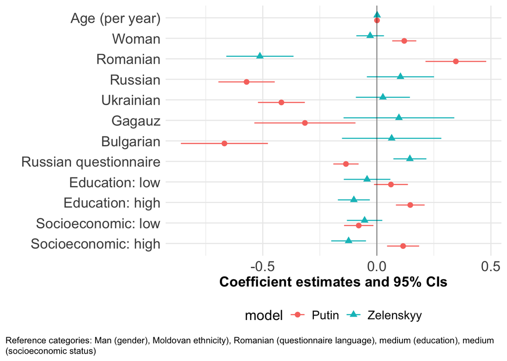

- Age: not significant
- Gender: woman significant for Putin (-)
- Ethnicity:
  - Romanian: significant for Zelenskyy (+) and Putin (-)
  - Russian, Ukrainian, Gagauz, Bulgarian: significant for Putin (+); not significant for Zelenskyy
- Russian questionnaire: significant for Putin (+) and Zelenskyy (-)
- Education: low not significant; high significant for Zelenskyy (+) and Putin (-)
- Socioeconomic: low significant for Putin (+) and high significant for Zelenskyy (+) and Putin (-)

## Geography

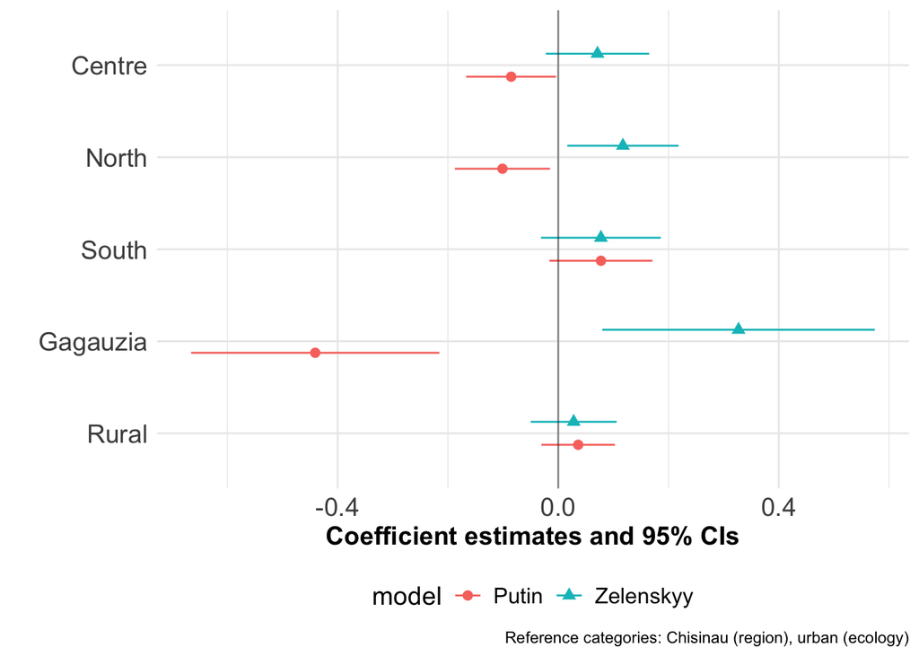

- Region:
  - Gagauzia: significant for Putin (+) and Zelenskyy (-)
  - Centre & North: significant for Putin (+); south not significant
- Ecology: not significant

## Attitudes

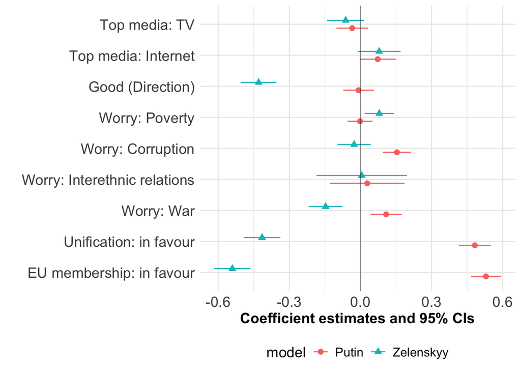

- Media: not significant
- Good direction: significant in support for Zelenskyy (+)
- Worries:
  - Poverty: significant in support for Zelenskyy (-)
  - Corruption: significant in support for Putin (-)
  - War: significant in support for Zelenskyy (+) and Putin (-)
- EU membership: significant in support for Zelenskyy (+) and Putin (-)
- Unification: significant in support for Zelenskyy (+) and Putin (-)

# Unification

Support for unification as rising over time: from 21% in 2017 to over 35% in 2025.

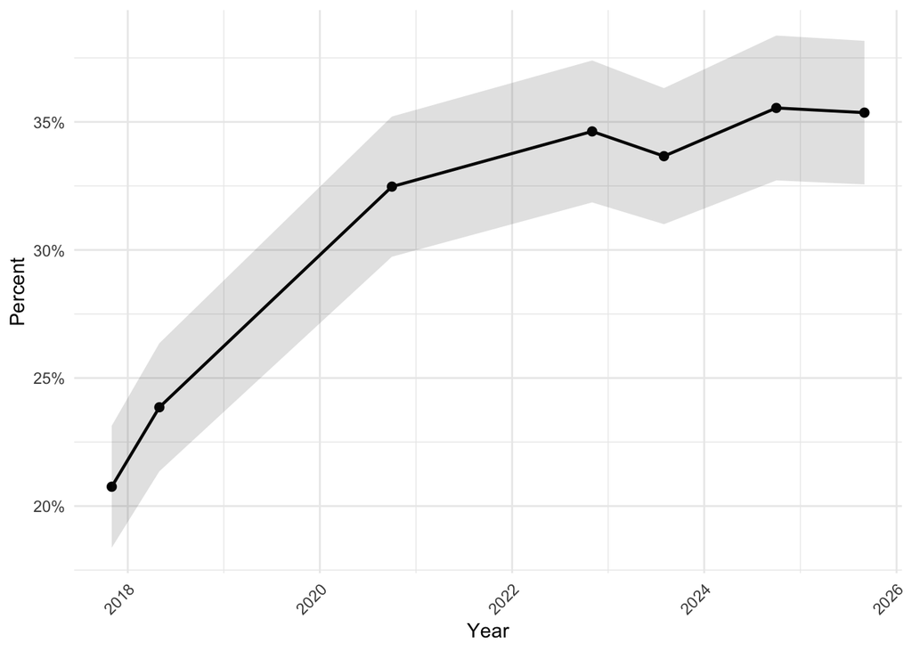

*Those supporting EU membership and NATO membership as more likely to support unification. Those identifying as Romanian as more likely to support unification.*

## Demographics

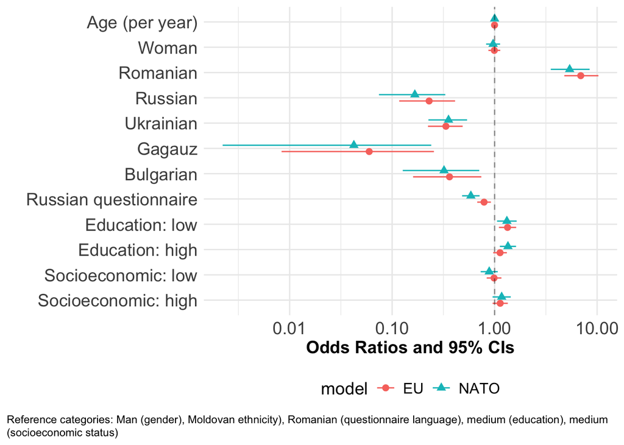

- Age & gender: not significant
- Ethnicity:
  - Romanian: significant (+)
  - Russian, Ukrainian, Gagauz, Bulgarian: significant (-)
- Russian questionnaire: significant (-)
- Education: low (+); high not consistently significant
- Socioeconomic: not significant

## Geography

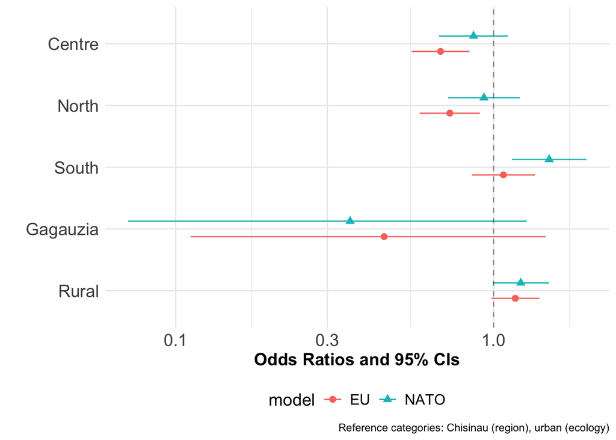

- Nothing consistently significant

## Attitudes

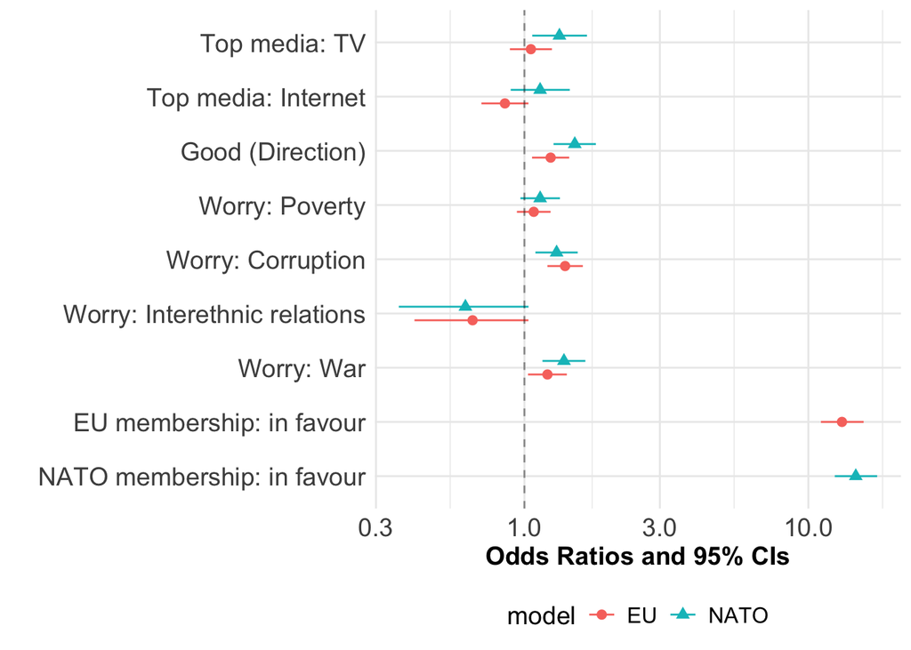

- Direction: good as significant (+)
- Worries: poverty and interethnic relations are not significant
  - Corruption: significant (+)
  - War: significant (+)
- EU membership: significant (+)
- NATO membership: significant (+)

# International Organisations

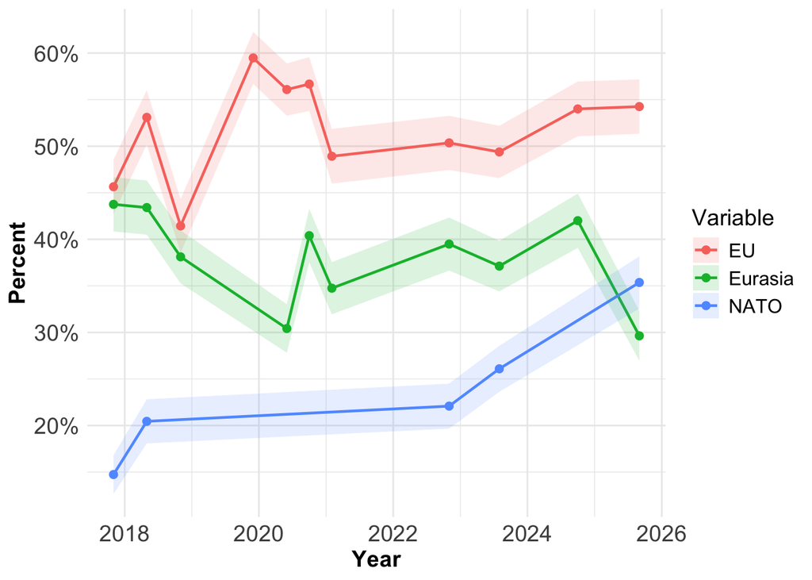

*Those supporting joining the Eurasian Union are older, and more likely Russian, Ukrainian, Bulgarian, or Gagauz. They are more likely to answer the questionnaire in Russia and be poorer. Those supporting it are more likely to live in Gaguazia or the North, and in urban areas. They are more likely to be concerned about poverty. Those naming TV and the internet are important sources of media are more likely to support joining.*

*Those with a high level of education or concerned about corruption are less likely to support joining the Eurasia Union Those thinking that Moldova is going in a good direction are less likely to support it.*

*Those who identify as Romanian are more likely to support joining the EU and NATO. Those with a high level of education are more likely to support joining the EU, while those with a high socioeconomic level are more likely to support joining the EU and NATO. Those residing in rural areas are more likely to support joining the EU. Those who think Moldova is heading in a good direction are more likely to support joining the EU and NATO.*

*Those concernd about corruption and war are more likely to support joining the EU and NATO.*

*Those residing in the South are less likely to support joining NATO but more likely to support joining the EU.*

*Those answering the questionnaire in Russian are less likely to support joining the EU and NATO. Those residing in Gagauzia are less likely to support joining the EU, and those residing in central and northern regions are less likely to support joining the EU and NATO. Those concerned about inter-ethnic relations are less likely to support joining the EU.*

## Demographics

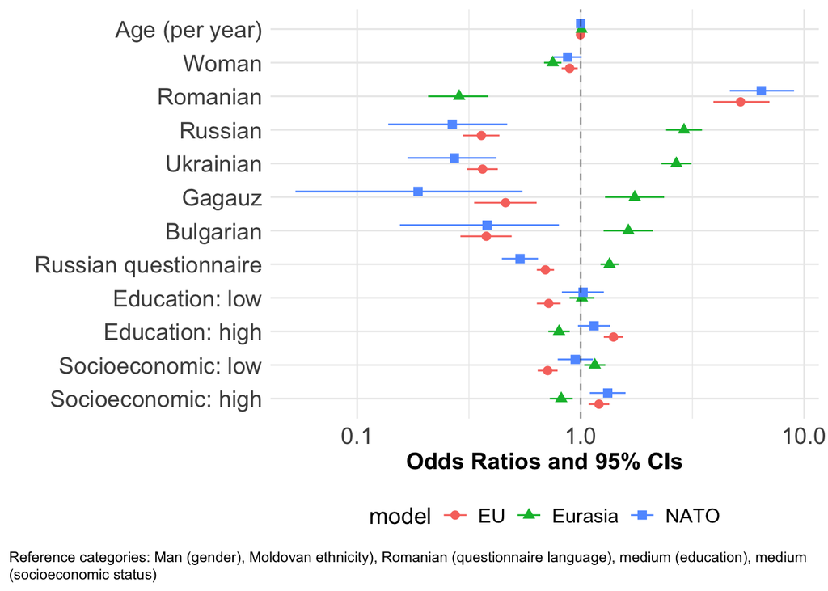

- Age: significant for Eurasia (+)
- Gender: women significant for EU and Eurasia (-)
- Ethnicity:
  - Romanian: significant for for EU and NATO (+), and Eurasia (-)
  - Russian, Ukrainian, Gagauz, Bulgarian: significant for EU and NATO (-), and Eurasia (+)
- Language: Russian as significant for EU and NATO (-) and Eurasia (+)
- Education: low as significant for EU (-); Eurasia and NATO not significant
  - High: significant for EU (+) and Eurasia (-)
- Socioeconomics: low as significant or EU (-) and Eurasia (+)
  - High: as significant for EU and NATO (+) and Eurasia (-)

## Geography

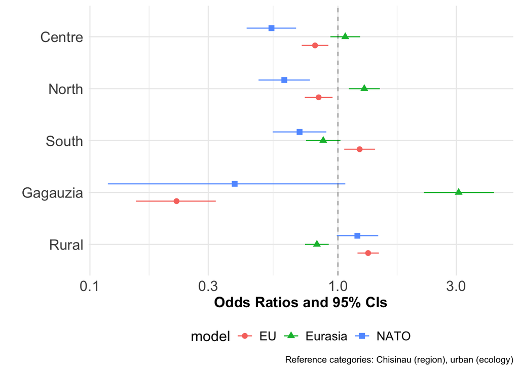

- Region
  - Gagauzia: significant for Eurasia (+) and EU (-)
  - Centre: significant for NATO and EU (-); not significant for Eurasia
  - North: significant for NATO and EU (-) and Eurasia (+)
  - South: significant fro NATO (-) and EU (+); not significant for Eurasia
- Ecology: rural as significant for EU (+) and Eurasia (-)

## Attitudes

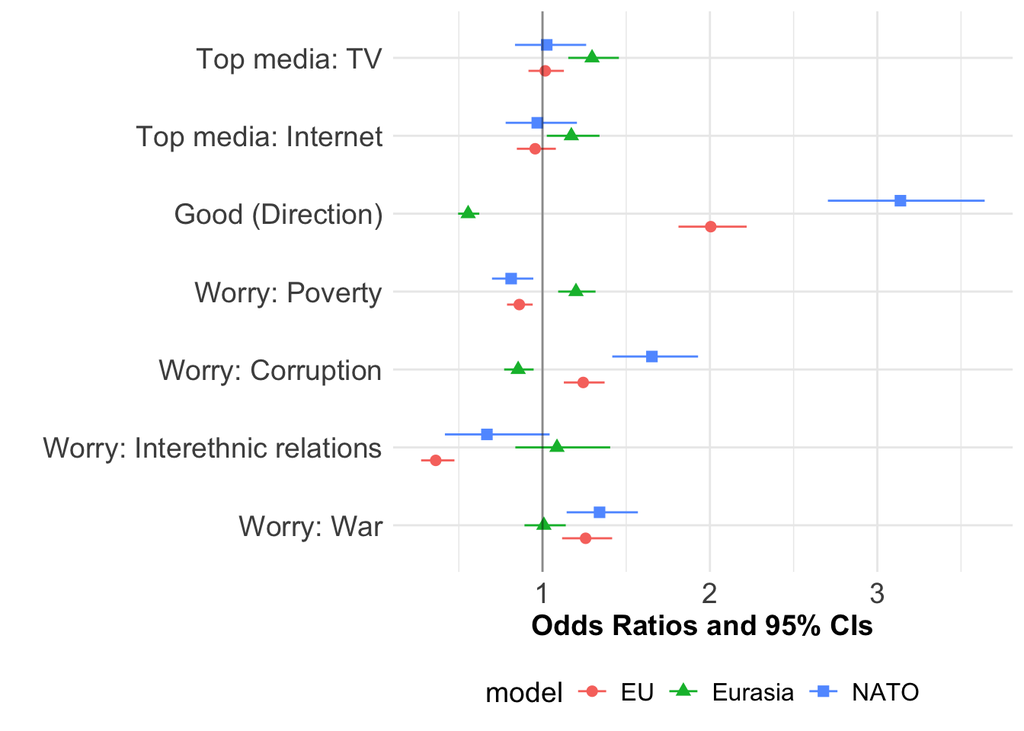

- Direction: good as significant for EU and NATO (+) and Eurasia (-)
- Worries:
  - Poverty: significant for EU and NATO (-) and Eurasia (+)
  - Corruption: significant for EU and NATO (+) and Eurasia (-)
  - Inter-ethnic relations: significant for EU (-)
  - War: significant for EU and NATO (+)
- Media: TV as significant for Eurasia (+); not significant for others
  - Internet as significant for Eurasia (+)